# Análise de RNA-seq: GSE128198

Fernando

2026-06-16

# 1. Introdução

Este relatório apresenta a análise de expressão diferencial do projeto **GSE128198**, investigando o papel de um enhancer imunológico na regulação de células Treg e Tconv (modelo *Mus musculus*). O design do estudo é um fatorial 2x2.

# 2. Expressão Diferencial (DESeq2) e PCA

Com as contagens importadas, inicializamos o objeto do DESeq2. Seguindo o delineamento do estudo, utilizamos um design fatorial (`~ cell_type * enhancer_ko`) para avaliar o efeito do nocaute do enhancer nos diferentes tipos celulares.

```r
# 1. Criar o objeto DESeqDataSet
dds <- DESeqDataSetFromTximport(txi,
                                colData = samples,
                                design = ~ cell_type * enhancer_ko)

# 2. Filtragem de genes com baixa expressão (ruído)
# Mantemos apenas genes com pelo menos 10 reads em 3 ou mais amostras
keep <- rowSums(counts(dds) >= 10) >= 3
dds <- dds[keep,]
print(paste("Genes retidos após filtragem:", nrow(dds)))
```

```
## [1] "Genes retidos após filtragem: 11511"
```

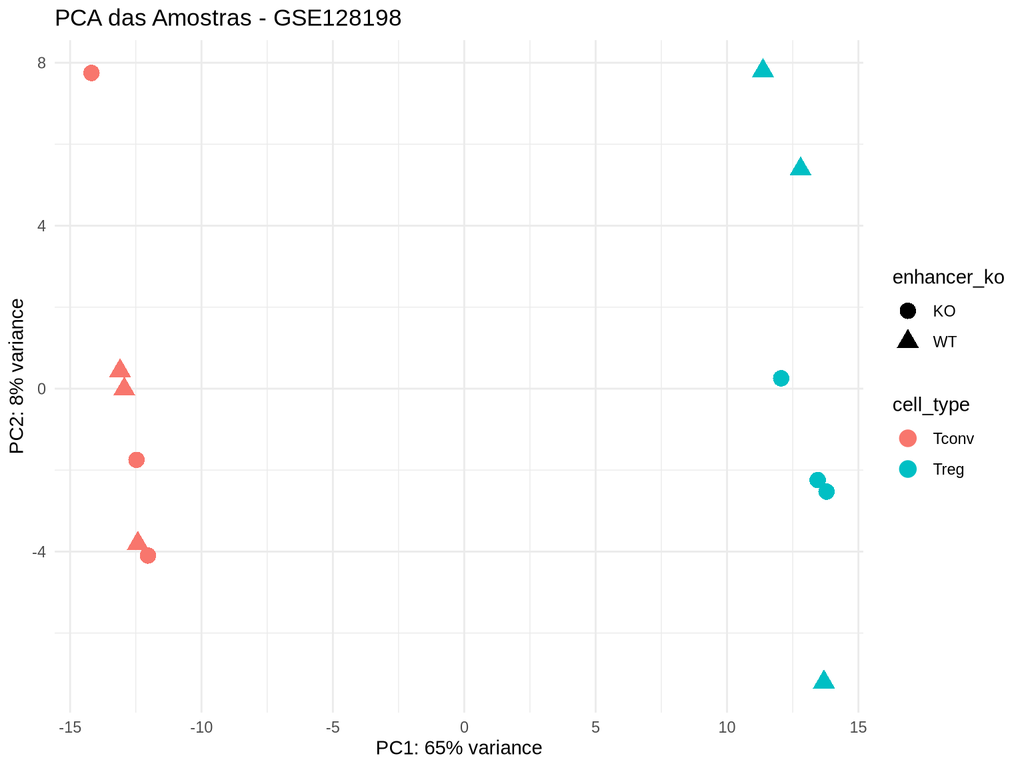

```r
# 3. Executar o pipeline estatístico do DESeq2
dds <- DESeq(dds)

# 4. Transformação estabilizadora de variância (VST) para visualização
vsd <- vst(dds, blind=FALSE)

# 5. Gráfico de PCA
pca_data <- plotPCA(vsd, intgroup=c("cell_type", "enhancer_ko"), returnData=TRUE)
percentVar <- round(100 * attr(pca_data, "percentVar"))

ggplot(pca_data, aes(PC1, PC2, color=cell_type, shape=enhancer_ko)) +
  geom_point(size=4) +
  xlab(paste0("PC1: ",percentVar[1],"% variance")) +
  ylab(paste0("PC2: ",percentVar[2],"% variance")) +
  theme_minimal() +
  ggtitle("PCA das Amostras - GSE128198")
```

# 3. Identificação de Genes Diferencialmente Expressos (DEGs)

Nesta etapa, extraímos os resultados estatísticos do DESeq2. Seguindo os critérios de rigor, definimos como Genes Diferencialmente Expressos (DEGs) aqueles que apresentam um P-valor ajustado (FDR) menor que 0.05 e uma mudança de expressão de pelo menos 2 vezes (Log2FC > 1 ou < -1).

```r
# 1. Extrair os resultados principais do modelo
res <- results(dds, alpha = 0.05)

# 2. Converter para DataFrame para facilitar a manipulação
res_df <- as.data.frame(res) %>%
  rownames_to_column(var = "Gene") %>%
  drop_na(padj, log2FoldChange)

# 3. Classificar os genes segundo os limiares do estudo
res_df <- res_df %>%
  mutate(Status = case_when(
    padj < 0.05 & log2FoldChange > 1 ~ "Up-regulated",
    padj < 0.05 & log2FoldChange < -1 ~ "Down-regulated",
    TRUE ~ "Não Significativo"
  ))

# Imprimir resumo de quantos genes encontramos
print("Resumo de Genes Encontrados:")
```

```
## [1] "Resumo de Genes Encontrados:"
```

```r
print(table(res_df$Status))
```

```
##
##    Down-regulated Não Significativo      Up-regulated
##                 4             11490                 5
```

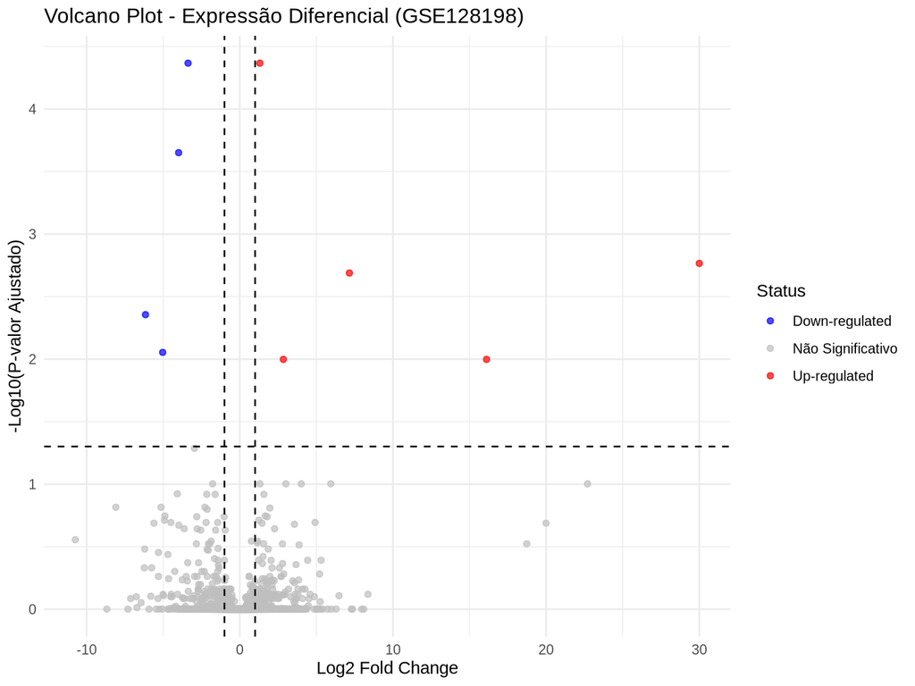

```r
# 4. Salvar a tabela completa em CSV (Boa prática profissional)
dir.create("results/deseq2", showWarnings = FALSE)
write.csv(res_df, "results/deseq2/tabela_DEGs_GSE128198.csv", row.names = FALSE)

# 5. Visualização: Volcano Plot
ggplot(res_df, aes(x = log2FoldChange, y = -log10(padj), color = Status)) +
  geom_point(alpha = 0.7, size = 1.5) +
  scale_color_manual(values = c("blue", "gray", "red")) +
  theme_minimal() +
  geom_vline(xintercept = c(-1, 1), linetype = "dashed", color = "black") +
  geom_hline(yintercept = -log10(0.05), linetype = "dashed", color = "black") +
  labs(title = "Volcano Plot - Expressão Diferencial (GSE128198)",
       x = "Log2 Fold Change",
       y = "-Log10(P-valor Ajustado)")
```

# 4. Enriquecimento Funcional (GO e KEGG)

Para interpretar biologicamente as alterações causadas pelo nocaute, utilizamos o pacote `clusterProfiler`. A análise busca vias metabólicas (KEGG) e processos biológicos (Gene Ontology) onde nossos DEGs estão super-representados.

```r
library(clusterProfiler)
library(org.Mm.eg.db)

# 1. Pegar a lista de genes significativos
sig_genes <- subset(res_df, Status != "Não Significativo")$Gene

# Os IDs do Ensembl geralmente vêm com versão (ex: ENSMUSG000000123.4)
# Precisamos remover o ponto e o número final para o banco de dados reconhecer
sig_genes_clean <- gsub("\\..*", "", sig_genes)

# 2. Converter IDs do Ensembl para Entrez ID e Symbol (Nomes dos genes)
gene_conv <- bitr(sig_genes_clean,
                  fromType = "ENSEMBL",
                  toType = c("ENTREZID", "SYMBOL"),
                  OrgDb = org.Mm.eg.db)

print(paste("Genes convertidos com sucesso:", nrow(gene_conv)))
```

```
## [1] "Genes convertidos com sucesso: 8"
```

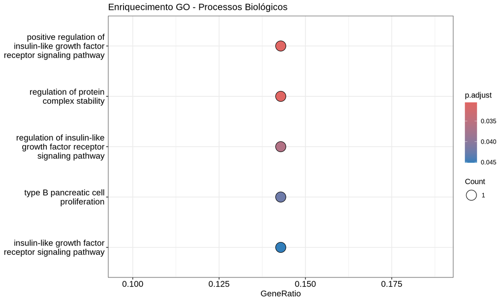

```
## [1] "Nenhuma via KEGG significativamente enriquecida."
```

```r
# 3. Análise Gene Ontology (Processos Biológicos)
if(nrow(gene_conv) > 0) {
  ego <- enrichGO(gene = gene_conv$ENTREZID,
                  OrgDb = org.Mm.eg.db,
                  ont = "BP",
                  pAdjustMethod = "BH",
                  pvalueCutoff = 0.05,
                  readable = TRUE)

  if (!is.null(ego) && nrow(ego) > 0) {
    print(dotplot(ego, showCategory=10) + ggtitle("Enriquecimento GO - Processos Biológicos"))
  } else {
    print("Nenhum termo GO significativamente enriquecido (típico para listas muito curtas de genes).")
  }

  # 4. Análise KEGG (Vias Metabólicas)
  ekegg <- enrichKEGG(gene = gene_conv$ENTREZID,
                      organism = 'mmu', # mmu = Mus musculus
                      pvalueCutoff = 0.05)

  if (!is.null(ekegg) && nrow(ekegg) > 0) {
    print(dotplot(ekegg, showCategory=10) + ggtitle("Enriquecimento KEGG - Vias Metabólicas"))
  } else {
    print("Nenhuma via KEGG significativamente enriquecida.")
  }
}
```